# Statistical Computing

Practice Questions

# Question 1: Likelihood

Consider the density
$$f(x) = \frac{1 - cos(x - \theta)}{2 \pi}$$
on $0 \le x \le 2\pi$, where $\theta$ is a parameter between $-\pi$ and $\pi$. The following i.i.d. data arise from this density: 3.91, 4.85, 2.28, 4.06, 3.70, 4.04, 5.46, 3.53, 2.28, 1.96, 2.53, 3.88, 2.22, 3.47, 4.82, 2.46, 2.99, 2.54, 0.52, 2.50.

We wish to estimate $\theta$.

Graph the log likelihood function between $-\pi$ and $\pi$.

# Question 2: Mixture Distribution

A mixture distribution has a density as follows.

$$f(x) = \theta f_1(x) + (1-\theta) f_2(x)$$

This is a new distribution constructed as a mixture of two component distributions combined with mixing weights $\theta$. The mixing weights sum to 1. Mixture distribution can also be constructed with more than two components.

Simulate $N = 5000$ values from the following normal mixture: $\theta = 0.75$ and the two components have $N(0, 1)$ and $N(3, 1)$ distributions.

Graph the histogram and superimpose the density.

# Question 3: Uniform Distribution on the Sphere

The $d$-sphere is the set of all points $x \in R^d$ such that $||x|| = (x^Tx)^{1/2} = 1$. Random vectors uniformly distributed on the $d$-spere have equally likely directions. A method of generating this distribution uses a property of the multivariate normal distribution. If $X_1, \ldots, X_d$ are iid $N(0, 1)$, then $U = (U_1, \ldots, U_d)$ is uniformly distributed on the unit sphere in $R^d$, where

$$U_j = \frac{X_j}{(X_1^2 + \ldots + X_d^2)^{1/2}}, \qquad j = 1, \ldots, d.$$

Write a function to generate uniform variates on the $d$-sphere.

Generate a sample of 200 points uniformly distributed on the circle. Plot to illustrate.

Try doing this without a for loop.

# Question 4: Quantiles

If $U, V \sim U(0, 1)$ are independent, then

$$Z_1 = \sqrt{-2 \log U} \cos (2 \pi V),$$
$$Z_2 = \sqrt{-2 \log V} \sin (2 \pi U)$$

are independent standard normal variables.

Assume that you only have a uniform random number generator available.

Generate 100 values from a $\chi^2_5$ distribution using the above ideas.

Then graphically compare sample quantiles with theoretical quantiles. For the theoretical quantiles you can use the available R function.

# Question 5: Simulate from Linear Model

Simulate 200 values from the following model.

$y_i = 2 - 3 x_i + e_i, \qquad e_i \sim N(0, \sigma^2)$

Simulate $x_i \sim U(-1, 1)$. Set $\sigma^2 = 0.5$.

Estimate intercept and slope (and their standard errors) using least squares: $\hat{\beta} = (X'X)^{-1} X'Y$ (not `lm()`).

$$Var(\hat{\beta}) = \hat{\sigma} (X'X)^{-1}$$

Compare these with the `lm()` output. The values should be exactly(!) the same.

Plot the observations and add the true line and the estimated regression line. Add a legend to label the lines.

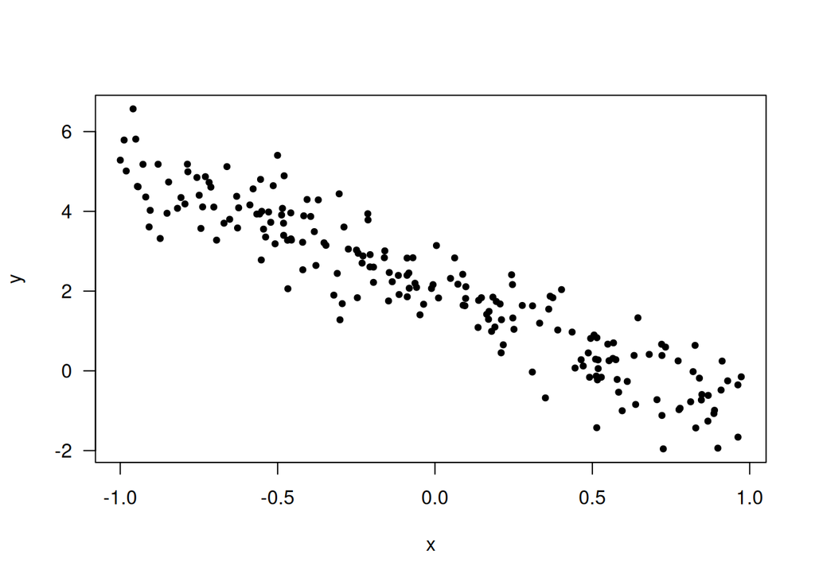

# Question 6: Simulate from model

Repeat Question 5, but now simulate 200 data points from the following model:

$y_t = 10 - 2 \cos(2 \pi t / j) + 3 \sin(2 \pi t / j) + 0.05 t + e_i, \qquad e_i \sim N(0, \sigma^2)$

$t = 1, \ldots, 200$. Set $\sigma^2 = 1.5$, $j = 50$.

Note: the $\cos$ and $\sin$ terms are known, i.e. treat these like x-variables. $j$ is known. The rest are parameters. This function as a seasonal pattern which repeats every 50 time steps. The cosine and sine arguments are in radians. $2 \pi$ is a full cycle, $t/j$ measures where in the cycle we are. There is also a trend term.

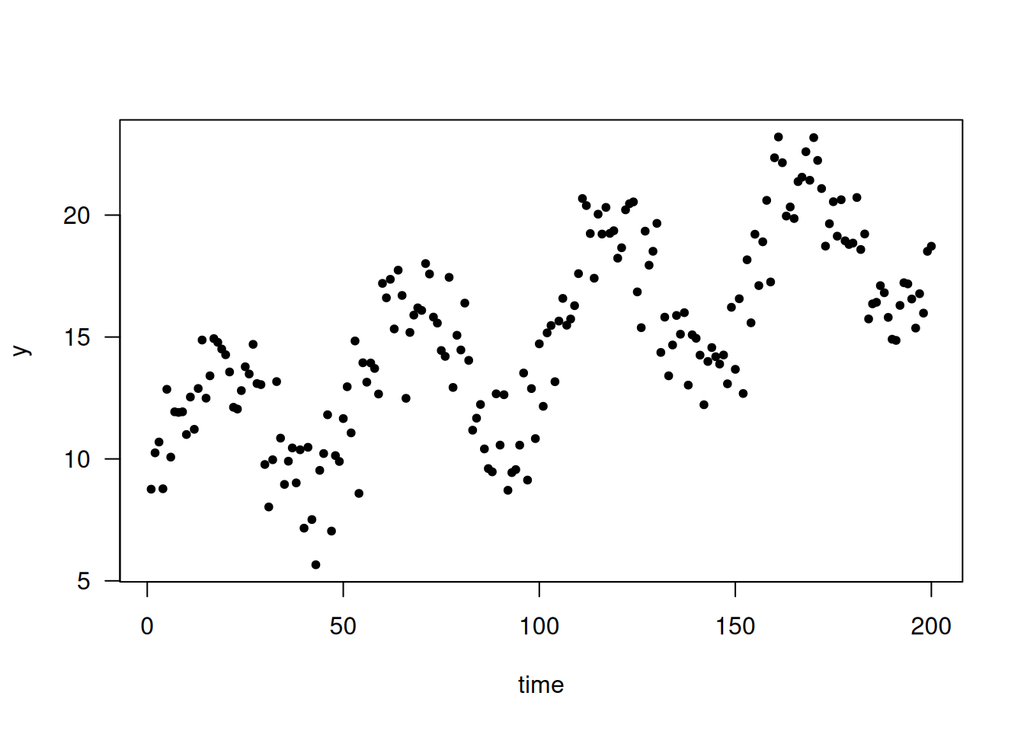

# Question 7: Least Squares Seals

Fit a non-linear model (logistic growth) to data using least squares, i.e. minimize the error sum of squares. Logistic growth models are often used when the growth rate per capita or individual is initially constant (exponential growth) but then becomes limited by carrying capacity. This can be used for populations of animals or cells, sometimes for the growth of individuals, and in many other situations.

The data here are on a population of seals counted between 1975 and 2000 (data file: `seals.csv`).

The logistic growth curve is:

$$P_t = \displaystyle \frac{K}{1 + e^{P_0 + rt}}$$

where $P_t$ is the population size at time $t$, $K$ is carrying capacity, $r$ is the population growth rate (here would be per year), and $t$ is time. $P_0$ is population size at time 0.

Here we assume that the average population growth can be modelled using the above logistic growth curve, and that the observed counts show some random variation around this average. If we assume constant variance of this error term, we can use least squares to fit the curve to the data.

- Plot the data over time.
- Write a function that will calculate the error sum of squares (in terms of $P_0$, $K$ and $r$) when fitting the logistic growth curve to these data.
- Try to plot this function. You may need to fix some of the parameters.
- Use R’s `nls()` function to fit the model and illustrate your results.

# Question 8: Randomization Test

Verizon was an Incumbent Local Exchange Carrier (ILEC), responsible for maintaining land-line phone service. Verizon also sold long-distance service, as did a number of competitors, termed Competitive Local Exchange Carriers (CLEC). When something went wrong, Verizon was responsible for repairs, and was supposed to make repairs as quickly for CLEC long-distance customers as for their own. A Public Utilities Commission (PUC) monitored fairness by comparing repair times for Verizon and different CLECs, for different classes of repairs and time periods. In each case a hypothesis test was performed at the 1% significance level, to determine whether repairs for CLEC’s customers were slower than for Verizon’s customers. There were hundreds of such tests. If substantially more than 1% of the tests were significant, then Verizon would pay large penalties. These tests were performed using $t$ tests; Verizon proposed using permutation tests instead.

The data for one combination of CLEC, class of service, and period are given in file `verizon.csv`. The one-sided permutation test p-value is 0.0171, well above the 1% cutoff mandated by the PUC. In comparison, the pooled $t$-test $p$-value is 0.0045, about four times too small. The permutation test gives the correct answer, with nearly exact Type 1 error rates. The t-test is inaccurate because it is sensitive to skewness when the sample sizes differ. Using $t$-tests for 10,000 Verizon fairness tests would result in about 400 false positive results instead of the expected 100, resulting in large monetary penalties. Similarly, $t$-confidence intervals are inaccurate.

Replicate the $t$-test and permutation test results. For the $t$-test you can use existing R functions. The permutation test you should write your own function, but you can use a randomization test.

Note: randomization tests are like permutation tests, except that they take a large number of possible randomizations instead of all possible randomizations. In a permutation / randomzation test the null hypothesis is that the 2 samples come from the same population. The test simulates a large number of (all possible) random permutations from this population into two groups of sizes $n_1$ and $n_2$, each time calculating the test statistics, thereby constructing the null / reference distribution.

Discuss your results and put into context, i.e. what should the decision about Verizon be?